# Avaliação Final — Ecologia Geral 2

Departamento de Botânica | Centro de Biociências | UFPE

Author

Felipe Melo

Universidade Federal de Pernambuco · Departamento de Botânica · CB

# Avaliação Final Integradora

Ecologia Geral 2 — Ecologia de Comunidades & Aplicações

Semestre 2026.1 · Avaliação Presencial com Consulta Prévia · Valor: 10,0 pontos

## Instruções Gerais

**Leia com atenção antes de começar.** Esta avaliação é individual e deve ser estudada antes para ser respondida na pŕoxima quianta-feira dia 18 de Junho de 2026. Você poderá consultar livros, artigos e anotações de aula, estude mesmo mas em casa. Você terá que escrver com suas palavras e não poderá usar anotações no dia da prova.

⚠️ **Sobre autoria e integridade acadêmica:** As respostas devem refletir sua própria compreensão, articulação e raciocínio. Respostas excessivamente genéricas, sem ancoragem no cenário proposto, ou que não demonstrem capacidade de aplicar os conceitos de forma contextualizada, não receberão pontuação integral — independentemente da fluência textual. Eu vou avaliar *como* você pensa, não apenas *o que* você escreve.

**Critérios de avaliação por questão:**

| Dimensão | O que será observado |
| --- | --- |
| **Precisão conceitual** | Uso correto e rigoroso de termos, definições e princípios ecológicos |
| **Aplicação** | Capacidade de relacionar conceitos ao cenário e à região neotropical |
| **Raciocínio abstrato** | Elaboração de hipóteses, relações causais e inferências não triviais |
| **Profundidade** | Integração entre tópicos, citação de mecanismos e discussão de nuances |

## O Cenário

Você é pesquisador(a) recém-contratado(a) pelo **Programa de Restauração dos Biomas de Pernambuco**, vinculado à UFPE. Seu primeiro projeto envolve uma área de **800 hectares** no **Agreste pernambucano**, uma zona de transição entre a Caatinga e a Mata Atlântica — faixa denominada localmente como [*“Mata Seca de Brejos de Altitude”*](https://parqueserradoscavalos.caruaru.pe.gov.br/wp-content/uploads/2019/12/Srie-Biodiversidade-09-Brejos-de-Altitude-em-Pernambuco-e-Paraba-Histria-Natural-Ecologia-e-Conservao.pdf).

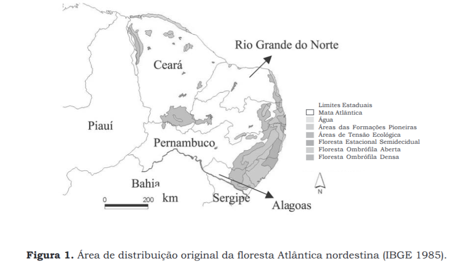

Os brejos de altitude são “ilhas” de floresta úmida (Mata Atlântica) encravadas na região semiárida do Nordeste brasileiro (Caatinga). A sua origem biogeográfica e a rica biodiversidade que abrigam são explicadas principalmente por flutuações climáticas históricas ocorridas durante o período Quaternário (especialmente no Pleistoceno).

O processo biogeográfico baseia-se nos seguintes pontos principais:

**1. Teoria dos Refúgios Florestais e Flutuações Climáticas** Durante as fases glaciais do Quaternário, o clima global tornou-se mais frio e seco. No Nordeste do Brasil, a caatinga se expandiu, e as florestas úmidas (que antes ocupavam áreas contínuas) retraíram-se, sobrevivendo apenas em refúgios isolados no topo de serras e planaltos (geralmente acima de 500 a 600 metros de altitude). Nessas altitudes, o relevo provoca chuvas orográficas e mantém temperaturas mais amenas e maior umidade, permitindo a sobrevivência da vegetação florestal.

Nas fases interglaciais (mais quentes e úmidas), as florestas se expandiam a partir desses refúgios, chegando a se reconectar temporariamente com as florestas costeiras e amazônicas.

**2. Conexões Históricas (Pontes Biogeográficas)** A biota dos brejos de altitude revela uma origem mista, evidenciando que essas ilhas de mata estiveram conectadas a dois grandes blocos florestais sul-americanos:

Mata Atlântica Costeira: É a influência biogeográfica predominante. A proximidade geográfica facilitou conexões frequentes durante os períodos mais úmidos, explicando por que a maior parte das espécies de plantas, aves e anfíbios dos brejos é compartilhada com a floresta costeira.

Amazônia: Diversos estudos taxonômicos (de plantas, borboletas e aves) identificam espécies que são disjunções amazônicas. Isso sugere a existência de “corredores” antigos de floresta úmida que cortavam o atual semiárido, interligando a Amazônia ao Nordeste do Brasil em períodos passados de umidade extrema.

**3. Isolamento e Endemismo** O subsequente retorno do clima seco (como o observado atualmente) isolou novamente essas florestas no topo das serras, cercadas pelo “mar” de Caatinga. Esse isolamento prolongado funcionou como um laboratório evolutivo:

Algumas espécies de climas úmidos ficaram ilhadas e adaptaram-se localmente.

O isolamento geográfico impediu o fluxo gênico com as populações da costa ou da Amazônia, levando ao surgimento de espécies endêmicas (exclusivas) de animais e plantas em determinados brejos.

Em resumo, os brejos de altitude são relíquias biogeográficas de antigas florestas contínuas, cuja origem e composição atual resultam da dinâmica de expansão, retração, isolamento e conexão florestal moldada pelas mudanças climáticas do passado.

A região apresenta o seguinte histórico de uso da terra:

- **Décadas de 1970–1990:** pecuária extensiva e exploração madeireira, com supressão quase total da vegetação nativa.
- **1990–2010:** abandono gradual das atividades econômicas; recolonização espontânea por espécies pioneiras (principalmente *Croton* spp. e gramíneas exóticas como *Melinis minutiflora*).
- **2010–2020:** tentativas pontuais de restauração ativa sem planejamento baseado em evidências.
- **2020–presente:** monitoramento contínuo de parcelas permanentes, coleta de dados de solo, clima, diversidade florística e fauna de polinizadores e dispersores.

Os dados preliminares indicam: **alta variabilidade espacial de solos** (desde latossolos profundos nas cotas mais altas até solos rasos e rochosos em encostas), **dois gradientes climáticos marcados** (altitude e continentalidade), e **fragmentação severa** da paisagem, com a área de estudo situada entre dois remanescentes de vegetação nativa a 12 km de distância.

> **Importante:** Todas as questões devem ser respondidas tendo este cenário como ponto de partida. Respostas dissociadas do contexto apresentado não receberão pontuação máxima.

## Questões

Questão 1 · Bases teóricas de comunidades

A natureza da comunidade: entre a integração e o individualismo

Ao iniciar o mapeamento florístico da área, você e sua equipe observam que a distribuição das espécies lenhosas **não** forma agrupamentos discretos e bem delimitados ao longo do gradiente altitudinal — em vez disso, cada espécie parece atingir seu pico de abundância em pontos distintos do gradiente, com sobreposições amplas entre elas.

**(a)** Esse padrão é mais consistente com a visão **clementsiana** (superorganismo) ou com a visão **gleassoniana** (continuum individualístico) de comunidade? Justifique sua resposta com base no que foi observado, explicando os pressupostos e as implicações práticas de cada perspectiva para o manejo desta área. *(1,5 pt)*

**(b)** Considerando que, ao mesmo tempo, você observa certas combinações de espécies que se repetem de forma não aleatória em microsítios de solo similar — como você integraria essa evidência com sua resposta ao item (a)? Que abordagem teórica contemporânea permitiria acomodar ambos os padrões simultaneamente? *(1,0 pt)*

Precisão conceitual Raciocínio abstrato Profundidade

Valor total: 2,5 pt

Questão 2 · Comunidades no espaço e no tempo

Biogeografia de ilhas e a fragmentação como laboratório

A área de estudo pode ser interpretada como arquipélagos de habitats em uma matriz de pastagem degradada.

**(a)** Aplique os princípios da **Teoria da Biogeografia de Ilhas (TBI)** de MacArthur & Wilson para descrever a dinâmica esperada de riqueza de espécies de aves florestais nos brejos de altitude considerando que a restauração promovida por sua equipe aumenta a conectividade das manchas de brejo. Considere explicitamente os parâmetros de **área**, **distância** e **taxas de colonização e extinção** em sua análise hipotética. *(1,5 pt)*

**(b)** Um colega sugere que a TBI é insuficiente para explicar a montagem de comunidades em paisagens fragmentadas como essa e propõe usar a **A spintese Moderna da Ecologia de Comunidades (Vellend 2010)** e as métricas de diversidade **alfa, beta e gama**. Em que aspectos específicos essa abordagem agrega informação que a TBI não contempla? Combine as duas abordagens para explicar a distribuição da diversidade entre os brejos de altitude. *(1,0 pt)*

Precisão conceitual Aplicação Profundidade

Valor total: 2,5 pt

Questão 3 · Determinantes abióticos da montagem de comunidades

Solo e clima como filtros da comunidade

Os dados de solo coletados nas parcelas permanentes revelam que, nas encostas rochosas (solos rasos, pH ácido, baixo teor de P), a cobertura vegetal é dominada por **cactáceas** e **bromeliáceas terrestres**, enquanto nas cotas mais altas (latossolos profundos, maior umidade edáfica) predominam espécies arbóreas de folhas largas com alta área foliar específica (AFE).

**(a)** Utilizando o conceito de **filtros abióticos** e **espaço de nicho**, explique de que forma as propriedades do solo e o microclima estão atuando como filtros na montagem das comunidades vegetais observadas. Diferencie claramente o papel do **filtro de habitat** do papel da **limitação de dispersão** para os padrões descritos. *(1,5 pt)*

**(b)** *Questão-problema:* Se você introduzir artificialmente mudas de uma espécie arbórea de alto dossel — típica da Mata Atlântica — nos microsítios rochosos com solos rasos, qual seria sua previsão sobre o estabelecimento a longo prazo dessa espécie? Desenvolva seu raciocínio mencionando ao menos dois processos ecológicos distintos que atuariam sobre essas plantas nos primeiros 5 anos. *(1,0 pt)*

Precisão conceitual Aplicação Raciocínio abstrato

Valor total: 2,5 pt

Questão 4 · Sucessão Ecológica

Trajetórias sucessionais em um sistema perturbado

**(c)** Proponha **uma única intervenção de manejo** — fundamentada ecologicamente — que poderia “desbloquear” a trajetória sucessional nas parcelas estagnadas. Explique o mecanismo ecológico pelo qual essa intervenção agiria. *(0,5 pt)*

Precisão conceitual Aplicação Raciocínio abstrato Profundidade

Valor total: 2,5 pt

## Distribuição de Pontos

| Questão | Tema principal | Pontos |
| --- | --- | --- |
| Q1 (a+b) | Bases teóricas de comunidades | 2,5 |
| Q2 (a+b) | Biogeografia e metacomunidades | 2,5 |
| Q3 (a+b) | Filtros abióticos (solo e clima) | 2,5 |
| Q4 (a+b+c) | Sucessão ecológica | 2,5 |
| **Total** |  | **10,0** |